# lab-05

Courtney Stowers

2024-04-12

# Introduction

## Diff-in-Diff models

For our analysis of the effectiveness of the New Markets Tax Credit (NMTC) and Low Income Housing Tax Credit (LIHTC) as a tool for community revitalization and the reduction of social vulnerability in neighborhoods across the Middle Atlantic Division, we will employ a Diff-In-Diff model of linear regression.

Diff-In-Diff models are a statistical technique that allows us to analyze the differences in differences of changes across time periods to determine whether our program intervention resulted in an additional increase or decrease beyond what we would expect following general trends in similar controls.

## Independent Variables: NMTC and LIHTC Data

# Library

```r
# Load packages
library(here)         # relative filepaths for reproducibility
library(rio)          # read excel file from URL
library(tidyverse)    # data wrangling
library(stringi)      # string data wrangling
library(tidycensus)   # US census data
library(ggplot2)      # data visualization
library(kableExtra)   # table formatting
library(scales)       # palette and number formatting
library(unhcrthemes)  # data visualization themes
library(ggrepel)      # data visualization formatting to avoid overlapping
library(rcompanion)   # data visualization of variable distribution
library(ggpubr)       # data visualization of variable distribution
library(moments)      # measures of skewness and kurtosis
library(tinytable)    # format regression tables
library(modelsummary) # format regression tables
```

# Load Functions

```r
import::here( "fips_census_regions",
              "load_svi_data",
              "merge_svi_data",
              "census_division",
              "slopegraph_plot",
              "census_pull",
             # notice the use of here::here() that points to the .R file
             # where all these R objects are created
             .from = here::here("analysis/project_data_steps_courtney.R"),
             .character_only = TRUE)
```

```r
# Load API key, assign to TidyCensus Package
source(here::here("analysis/password.R"))
census_api_key(.census_api_key)
```

```
## To install your API key for use in future sessions, run this function with `install = TRUE`.
```

# Data

```r
# Load NMTC AND LIHTC data sets

svi_divisional_nmtc <- readRDS(here::here(paste0("data/wrangling/", str_replace_all(census_division, " ", "_"), "_svi_divisional_nmtc.rds")))

svi_national_nmtc <- readRDS(here::here(paste0("data/wrangling/", str_replace_all(census_division, " ", "_"), "_svi_national_nmtc.rds")))

svi_divisional_lihtc <- readRDS(here::here(paste0("data/wrangling/", str_replace_all(census_division, " ", "_"), "_svi_divisional_lihtc.rds")))

svi_national_lihtc <- readRDS(here::here(paste0("data/wrangling/", str_replace_all(census_division, " ", "_"), "_svi_national_lihtc.rds")))
```

## House Price Index Data

```r
hpi_df <- read.csv("https://www.fhfa.gov/DataTools/Downloads/Documents/HPI/HPI_AT_BDL_tract.csv")

hpi_df_10_20 <- hpi_df %>%
  mutate(GEOID10 = str_pad(tract, 11, "left", pad=0)) %>%
  filter(year %in% c(2010, 2020))  %>%
 select(GEOID10, state_abbr, year, hpi) %>%
  pivot_wider(names_from = year, values_from = hpi) %>%
  mutate(housing_price_index10 = `2010`,
         housing_price_index20 = `2020`) %>%
  select(GEOID10, state_abbr, housing_price_index10, housing_price_index20)

# View data
hpi_df_10_20 %>% head() %>% kbl() %>% kable_styling() %>% scroll_box(width = "100%")
```

| GEOID10 | state_abbr | housing_price_index10 | housing_price_index20 |
| --- | --- | --- | --- |
| 01001020100 | AL | 132.35 | 152.78 |
| 01001020200 | AL | 123.78 | 123.37 |
| 01001020300 | AL | 158.57 | 167.01 |
| 01001020400 | AL | 165.11 | 179.60 |
| 01001020501 | AL | 172.55 | 180.96 |
| 01001020502 | AL | 158.75 | 164.25 |

```r
# Drop state_abbr column for joining
hpi_df_10_20 <- hpi_df_10_20 %>% select(-state_abbr)
```

## CBSA Crosswalk Data

```r
msa_csa_crosswalk <- rio::import("https://r-class.github.io/paf-515-course-materials/data/raw/CSA_MSA_Crosswalk/qcew-county-msa-csa-crosswalk.xlsx", which=4)

msa_csa_crosswalk <- msa_csa_crosswalk %>%
  mutate(county_fips = str_pad(`County Code`, 5, "left", pad=0),
         cbsa = coalesce(`CSA Title`, `MSA Title`),
         cbsa_code = coalesce(`CSA Code`, `MSA Code`),
         county_title = `County Title`)  %>%
  select(county_fips, county_title, cbsa, cbsa_code)

msa_csa_crosswalk %>% head() %>% kbl() %>% kable_styling() %>% scroll_box(width = "100%")
```

| county_fips | county_title | cbsa | cbsa_code |
| --- | --- | --- | --- |
| 01001 | Autauga County, Alabama | Montgomery-Alexander City, AL CSA | CS388 |
| 01003 | Baldwin County, Alabama | Mobile-Daphne-Fairhope, AL CSA | CS380 |
| 01005 | Barbour County, Alabama | Eufaula, AL-GA MicroSA | C2164 |
| 01007 | Bibb County, Alabama | Birmingham-Hoover-Cullman, AL CSA | CS142 |
| 01009 | Blount County, Alabama | Birmingham-Hoover-Cullman, AL CSA | CS142 |
| 01015 | Calhoun County, Alabama | Anniston-Oxford, AL MSA | C1150 |

## Census Data

```r
states <- list(svi_national_nmtc$state %>% unique())
states
```

```
## [[1]]
##  [1] "AL" "AK" "AZ" "AR" "CA" "CO" "CT" "DE" "DC" "FL" "GA" "HI" "ID" "IL" "IN"
## [16] "IA" "KS" "KY" "LA" "ME" "MD" "MA" "MI" "MN" "MS" "MO" "MT" "NE" "NV" "NH"
## [31] "NJ" "NM" "NY" "NC" "ND" "OH" "OK" "OR" "PA" "RI" "SC" "SD" "TN" "TX" "UT"
## [46] "VT" "VA" "WA" "WV" "WI" "WY"
```

```r
census_pull10 <- lapply(states, census_pull, yr = 2010)

census_pull10_df <- census_pull10[[1]] %>%
  # Drop margin of error column
  select(-moe) %>%
  # Add suffix to variable names
  mutate(variable = paste0(variable, "_10")) %>%
  # Pivot data frame
  pivot_wider(
    names_from = variable,
    values_from = c(estimate)
  )

census_pull10_df %>% head(10) %>% kbl() %>% kable_styling() %>% scroll_box(width = "100%")
```

| GEOID | NAME | Median_Income_10 | Median_Home_Value_10 |
| --- | --- | --- | --- |
| 01001020100 | Census Tract 201, Autauga County, Alabama | 31769 | 120700 |
| 01001020200 | Census Tract 202, Autauga County, Alabama | 19437 | 138500 |
| 01001020300 | Census Tract 203, Autauga County, Alabama | 24146 | 111300 |
| 01001020400 | Census Tract 204, Autauga County, Alabama | 27735 | 126300 |
| 01001020500 | Census Tract 205, Autauga County, Alabama | 35517 | 173000 |
| 01001020600 | Census Tract 206, Autauga County, Alabama | 24597 | 110700 |
| 01001020700 | Census Tract 207, Autauga County, Alabama | 22114 | 93800 |
| 01001020801 | Census Tract 208.01, Autauga County, Alabama | 30841 | 258000 |
| 01001020802 | Census Tract 208.02, Autauga County, Alabama | 29006 | 145100 |
| 01001020900 | Census Tract 209, Autauga County, Alabama | 24841 | 108000 |

```r
census_pull19 <- lapply(states, census_pull, yr = 2019)

census_pull19_df <- census_pull19[[1]] %>%
  # Select columns
  select(GEOID, NAME, variable, estimate, moe) %>%
  # Create individual FIPS columns for state, county, and tract
  mutate(FIPS_st = substr(GEOID, 1, 2),
         FIPS_county = substr(GEOID, 3, 5),
         FIPS_tract = substr(GEOID, 6, 11)) %>%
# Los Angeles, CA Census Tract fixes
                      mutate(FIPS_tract2 = if_else((FIPS_county == "037" & FIPS_st == "06" & FIPS_tract == "137000"), "930401", FIPS_tract )) %>%
# Pima County, AZ Census Tract fixes
                      mutate(FIPS_tract2 = if_else((FIPS_county == "019" & FIPS_st == "04" & FIPS_tract == "002704"), "002701", FIPS_tract2 )) %>%
                      mutate(FIPS_tract2 = if_else((FIPS_county == "019" & FIPS_st == "04" & FIPS_tract == "002906"), "002903", FIPS_tract2 )) %>%
                      mutate(FIPS_tract2 = if_else((FIPS_county == "019" & FIPS_st == "04" & FIPS_tract == "004118"), "410501", FIPS_tract2 )) %>%
                      mutate(FIPS_tract2 = if_else((FIPS_county == "019" & FIPS_st == "04" & FIPS_tract == "004121"), "410502", FIPS_tract2 )) %>%
                      mutate(FIPS_tract2 = if_else((FIPS_county == "019" & FIPS_st == "04" & FIPS_tract == "004125"), "410503", FIPS_tract2 )) %>%
                      mutate(FIPS_tract2 = if_else((FIPS_county == "019" & FIPS_st == "04" & FIPS_tract == "005200"), "470400", FIPS_tract2 )) %>%
                      mutate(FIPS_tract2 = if_else((FIPS_county == "019" & FIPS_st == "04" & FIPS_tract == "005300"), "470500", FIPS_tract2 )) %>%
# Madison County, NY Census Tract fixes
                      mutate(FIPS_tract2 = if_else((FIPS_county == "053" & FIPS_st == "36" & FIPS_tract == "030101"), "940101", FIPS_tract2 )) %>%
                      mutate(FIPS_tract2 = if_else((FIPS_county == "053" & FIPS_st == "36" & FIPS_tract == "030102"), "940102", FIPS_tract2 )) %>%
                      mutate(FIPS_tract2 = if_else((FIPS_county == "053" & FIPS_st == "36" & FIPS_tract == "030103"), "940103", FIPS_tract2 )) %>%
                      mutate(FIPS_tract2 = if_else((FIPS_county == "053" & FIPS_st == "36" & FIPS_tract == "030200"), "940200", FIPS_tract2 )) %>%
                      mutate(FIPS_tract2 = if_else((FIPS_county == "053" & FIPS_st == "36" & FIPS_tract == "030300"), "940300", FIPS_tract2 )) %>%
                      mutate(FIPS_tract2 = if_else((FIPS_county == "053" & FIPS_st == "36" & FIPS_tract == "030401"), "940401", FIPS_tract2 )) %>%
                      mutate(FIPS_tract2 = if_else((FIPS_county == "053" & FIPS_st == "36" & FIPS_tract == "030403"), "940403", FIPS_tract2 )) %>%
                      mutate(FIPS_tract2 = if_else((FIPS_county == "053" & FIPS_st == "36" & FIPS_tract == "030600"), "940600", FIPS_tract2 )) %>%
                      mutate(FIPS_tract2 = if_else((FIPS_county == "053" & FIPS_st == "36" & FIPS_tract == "030402"), "940700", FIPS_tract2 )) %>%
# Oneida County, NY Census Tract fixes
                      mutate(FIPS_tract2 = if_else((FIPS_county == "065" & FIPS_st == "36" & FIPS_tract == "024800"), "940000", FIPS_tract2 )) %>%
                      mutate(FIPS_tract2 = if_else((FIPS_county == "065" & FIPS_st == "36" & FIPS_tract == "024700"), "940100", FIPS_tract2 )) %>%
                      mutate(FIPS_tract2 = if_else((FIPS_county == "065" & FIPS_st == "36" & FIPS_tract == "024900"), "940200", FIPS_tract2 )) %>%
                      # Move columns in data set
                      relocate(c(FIPS_st, FIPS_county, FIPS_tract, FIPS_tract2),.after = GEOID) %>%
                      # Create new GEOID column
                      mutate(GEOID = paste0(FIPS_st, FIPS_county, FIPS_tract2)) %>%
                      # Drop newly created FIPS columns and margin of error
                      select(-FIPS_st, -FIPS_county, -FIPS_tract, -FIPS_tract2, -moe) %>%
                      # Add suffix
                      mutate(variable = paste0(variable, "_19")) %>%
                      # Pivot data set
                      pivot_wider(
                        names_from = variable,
                        values_from = c(estimate)
                      )

census_pull19_df %>% head(10) %>% kbl() %>% kable_styling() %>% scroll_box(width = "100%")
```

| GEOID | NAME | Median_Income_19 | Median_Home_Value_19 |
| --- | --- | --- | --- |
| 01001020100 | Census Tract 201, Autauga County, Alabama | 25970 | 136100 |
| 01001020200 | Census Tract 202, Autauga County, Alabama | 20154 | 90500 |
| 01001020300 | Census Tract 203, Autauga County, Alabama | 27383 | 122600 |
| 01001020400 | Census Tract 204, Autauga County, Alabama | 34620 | 152700 |
| 01001020500 | Census Tract 205, Autauga County, Alabama | 41178 | 186900 |
| 01001020600 | Census Tract 206, Autauga County, Alabama | 21146 | 103600 |
| 01001020700 | Census Tract 207, Autauga County, Alabama | 20934 | 82400 |
| 01001020801 | Census Tract 208.01, Autauga County, Alabama | 31667 | 322900 |
| 01001020802 | Census Tract 208.02, Autauga County, Alabama | 33086 | 171500 |
| 01001020900 | Census Tract 209, Autauga County, Alabama | 32677 | 156900 |

```r
inflation_adj = 1.16

# Join 2010 and 2019 Median Income and Home Value Data
census_pull_df <- left_join(census_pull10_df, census_pull19_df[c("GEOID", "Median_Income_19", "Median_Home_Value_19")], join_by("GEOID" == "GEOID"))

# Create new inflation adjusted columns for 2010 median income and median home value, find changes over time
census_pull_df <- census_pull_df %>%
                   mutate(Median_Income_10adj = Median_Income_10*inflation_adj,
                          Median_Home_Value_10adj = Median_Home_Value_10*inflation_adj,
                          Median_Income_Change = Median_Income_19 - Median_Income_10adj,
                          Median_Income_Change_pct = (Median_Income_19 - Median_Income_10adj)/Median_Income_10adj,
                          Median_Home_Value_Change = Median_Home_Value_19 - Median_Home_Value_10adj,
                          Median_Home_Value_Change_pct = (Median_Home_Value_19 - Median_Home_Value_10adj)/Median_Home_Value_10adj)

# View data
census_pull_df %>% head(10) %>% kbl() %>% kable_styling() %>% scroll_box(width = "100%")
```

| GEOID | NAME | Median_Income_10 | Median_Home_Value_10 | Median_Income_19 | Median_Home_Value_19 | Median_Income_10adj | Median_Home_Value_10adj | Median_Income_Change | Median_Income_Change_pct | Median_Home_Value_Change | Median_Home_Value_Change_pct |
| --- | --- | --- | --- | --- | --- | --- | --- | --- | --- | --- | --- |
| 01001020100 | Census Tract 201, Autauga County, Alabama | 31769 | 120700 | 25970 | 136100 | 36852.04 | 140012 | -10882.04 | -0.2952900 | -3912 | -0.0279405 |
| 01001020200 | Census Tract 202, Autauga County, Alabama | 19437 | 138500 | 20154 | 90500 | 22546.92 | 160660 | -2392.92 | -0.1061307 | -70160 | -0.4366986 |
| 01001020300 | Census Tract 203, Autauga County, Alabama | 24146 | 111300 | 27383 | 122600 | 28009.36 | 129108 | -626.36 | -0.0223625 | -6508 | -0.0504074 |
| 01001020400 | Census Tract 204, Autauga County, Alabama | 27735 | 126300 | 34620 | 152700 | 32172.60 | 146508 | 2447.40 | 0.0760709 | 6192 | 0.0422639 |
| 01001020500 | Census Tract 205, Autauga County, Alabama | 35517 | 173000 | 41178 | 186900 | 41199.72 | 200680 | -21.72 | -0.0005272 | -13780 | -0.0686665 |
| 01001020600 | Census Tract 206, Autauga County, Alabama | 24597 | 110700 | 21146 | 103600 | 28532.52 | 128412 | -7386.52 | -0.2588807 | -24812 | -0.1932218 |
| 01001020700 | Census Tract 207, Autauga County, Alabama | 22114 | 93800 | 20934 | 82400 | 25652.24 | 108808 | -4718.24 | -0.1839309 | -26408 | -0.2427027 |
| 01001020801 | Census Tract 208.01, Autauga County, Alabama | 30841 | 258000 | 31667 | 322900 | 35775.56 | 299280 | -4108.56 | -0.1148426 | 23620 | 0.0789227 |
| 01001020802 | Census Tract 208.02, Autauga County, Alabama | 29006 | 145100 | 33086 | 171500 | 33646.96 | 168316 | -560.96 | -0.0166719 | 3184 | 0.0189168 |
| 01001020900 | Census Tract 209, Autauga County, Alabama | 24841 | 108000 | 32677 | 156900 | 28815.56 | 125280 | 3861.44 | 0.1340054 | 31620 | 0.2523946 |

# NMTC Data

```r
svi_divisional_nmtc_df0 <- left_join(svi_divisional_nmtc, census_pull_df, join_by("GEOID_2010_trt" == "GEOID"))

svi_divisional_nmtc_df1 <- left_join(svi_divisional_nmtc_df0, hpi_df_10_20, join_by("GEOID_2010_trt" == "GEOID10")) %>%
                          unite("county_fips", FIPS_st, FIPS_county, sep = "")

svi_divisional_nmtc_df <- left_join(svi_divisional_nmtc_df1, msa_csa_crosswalk, join_by("county_fips" == "county_fips"))

svi_divisional_nmtc_df %>% head(10) %>% kbl() %>% kable_styling() %>% scroll_box(width = "100%")
```

| GEOID_2010_trt | county_fips | FIPS_tract | state | state_name | county | region_number | region | division_number | division | E_TOTPOP_10 | E_HU_10 | E_HH_10 | E_POV150_10 | ET_POVSTATUS_10 | EP_POV150_10 | EPL_POV150_10 | F_POV150_10 | E_UNEMP_10 | ET_EMPSTATUS_10 | EP_UNEMP_10 | EPL_UNEMP_10 | F_UNEMP_10 | E_HBURD_OWN_10 | ET_HOUSINGCOST_OWN_10 | EP_HBURD_OWN_10 | EPL_HBURD_OWN_10 | F_HBURD_OWN_10 | E_HBURD_RENT_10 | ET_HOUSINGCOST_RENT_10 | … |
| --- | --- | --- | --- | --- | --- | --- | --- | --- | --- | --- | --- | --- | --- | --- | --- | --- | --- | --- | --- | --- | --- | --- | --- | --- | --- | --- | --- | --- | --- | --- |
| 34001000100 | 34001 | 000100 | NJ | New Jersey | Atlantic County | 1 | Northeast Region | 2 | Middle Atlantic Division | 2907 | 1088 | 983 | 1127 | 2907 | 38.76849 | 0.8482 | 1 | 144 | 1433 | 10.048849 | 0.7544 | 1 | 280 | 435 | 64.36782 | 0.9529 | 1 | 204 | 548 | … |
| 34001000200 | 34001 | 000200 | NJ | New Jersey | Atlantic County | 1 | Northeast Region | 2 | Middle Atlantic Division | 3189 | 2217 | 1473 | 519 | 3189 | 16.27469 | 0.4806 | 0 | 109 | 1558 | 6.996149 | 0.5179 | 0 | 573 | 955 | 60.00000 | 0.9323 | 1 | 199 | 518 | … |
| 34001000300 | 34001 | 000300 | NJ | New Jersey | Atlantic County | 1 | Northeast Region | 2 | Middle Atlantic Division | 3997 | 1823 | 1357 | 1401 | 3968 | 35.30746 | 0.8164 | 1 | 382 | 2238 | 17.068811 | 0.9376 | 1 | 176 | 329 | 53.49544 | 0.8855 | 1 | 604 | 1028 | … |
| 34001000500 | 34001 | 000500 | NJ | New Jersey | Atlantic County | 1 | Northeast Region | 2 | Middle Atlantic Division | 3483 | 1241 | 1027 | 1938 | 3483 | 55.64169 | 0.9533 | 1 | 124 | 1630 | 7.607362 | 0.5830 | 0 | 227 | 446 | 50.89686 | 0.8549 | 1 | 478 | 581 | … |
| 34001001100 | 34001 | 001100 | NJ | New Jersey | Atlantic County | 1 | Northeast Region | 2 | Middle Atlantic Division | 2204 | 1204 | 1204 | 1185 | 2204 | 53.76588 | 0.9457 | 1 | 219 | 927 | 23.624596 | 0.9830 | 1 | 97 | 172 | 56.39535 | 0.9094 | 1 | 462 | 1032 | … |
| 34001001300 | 34001 | 001300 | NJ | New Jersey | Atlantic County | 1 | Northeast Region | 2 | Middle Atlantic Division | 2153 | 1026 | 857 | 695 | 2153 | 32.28054 | 0.7840 | 1 | 266 | 1112 | 23.920863 | 0.9840 | 1 | 168 | 432 | 38.88889 | 0.6425 | 0 | 271 | 425 | … |
| 34001001400 | 34001 | 001400 | NJ | New Jersey | Atlantic County | 1 | Northeast Region | 2 | Middle Atlantic Division | 3736 | 1893 | 1503 | 2135 | 3736 | 57.14668 | 0.9592 | 1 | 411 | 1635 | 25.137615 | 0.9866 | 1 | 267 | 401 | 66.58354 | 0.9617 | 1 | 715 | 1102 | … |
| 34001001500 | 34001 | 001500 | NJ | New Jersey | Atlantic County | 1 | Northeast Region | 2 | Middle Atlantic Division | 1074 | 901 | 752 | 656 | 1074 | 61.08007 | 0.9700 | 1 | 43 | 270 | 15.925926 | 0.9242 | 1 | 30 | 70 | 42.85714 | 0.7276 | 0 | 366 | 682 | … |
| 34001001900 | 34001 | 001900 | NJ | New Jersey | Atlantic County | 1 | Northeast Region | 2 | Middle Atlantic Division | 1656 | 1159 | 903 | 524 | 1656 | 31.64251 | 0.7755 | 1 | 72 | 879 | 8.191126 | 0.6337 | 0 | 41 | 50 | 82.00000 | 0.9900 | 1 | 407 | 853 | … |
| 34001002300 | 34001 | 002300 | NJ | New Jersey | Atlantic County | 1 | Northeast Region | 2 | Middle Atlantic Division | 2251 | 1108 | 703 | 1183 | 2251 | 52.55442 | 0.9403 | 1 | 137 | 842 | 16.270784 | 0.9292 | 1 | 119 | 230 | 51.73913 | 0.8660 | 1 | 213 | 473 | … |

```r
svi_national_nmtc_df0 <- left_join(svi_national_nmtc, census_pull_df, join_by("GEOID_2010_trt" == "GEOID"))

svi_national_nmtc_df1 <- left_join(svi_national_nmtc_df0, hpi_df_10_20, join_by("GEOID_2010_trt" == "GEOID10")) %>%
                          unite("county_fips", FIPS_st, FIPS_county, sep = "")

svi_national_nmtc_df <- left_join(svi_national_nmtc_df1, msa_csa_crosswalk, join_by("county_fips" == "county_fips"))

svi_national_nmtc_df %>% head(10) %>% kbl() %>% kable_styling() %>% scroll_box(width = "100%")
```

| GEOID_2010_trt | county_fips | FIPS_tract | state | state_name | county | region_number | region | division_number | division | E_TOTPOP_10 | E_HU_10 | E_HH_10 | E_POV150_10 | ET_POVSTATUS_10 | EP_POV150_10 | EPL_POV150_10 | F_POV150_10 | E_UNEMP_10 | ET_EMPSTATUS_10 | EP_UNEMP_10 | EPL_UNEMP_10 | F_UNEMP_10 | E_HBURD_OWN_10 | ET_HOUSINGCOST_OWN_10 | EP_HBURD_OWN_10 | EPL_HBURD_OWN_10 | F_HBURD_OWN_10 | E_HBURD_RENT_10 | ET_HOUSINGCOST_RENT_10 | … |
| --- | --- | --- | --- | --- | --- | --- | --- | --- | --- | --- | --- | --- | --- | --- | --- | --- | --- | --- | --- | --- | --- | --- | --- | --- | --- | --- | --- | --- | --- | --- |
| 01001020200 | 01001 | 020200 | AL | Alabama | Autauga County | 1 | South Region | 6 | East South Central Division | 2020 | 816 | 730 | 495 | 1992 | 24.84940 | 0.5954 | 0 | 68 | 834 | 8.153477 | 0.57540 | 0 | 49 | 439 | 11.16173 | 0.02067 | 0 | 105 | 291 | … |
| 01001020700 | 01001 | 020700 | AL | Alabama | Autauga County | 1 | South Region | 6 | East South Central Division | 2664 | 1254 | 1139 | 710 | 2664 | 26.65165 | 0.6328 | 0 | 29 | 1310 | 2.213741 | 0.05255 | 0 | 134 | 710 | 18.87324 | 0.13890 | 0 | 187 | 429 | … |
| 01001021100 | 01001 | 021100 | AL | Alabama | Autauga County | 1 | South Region | 6 | East South Central Division | 3298 | 1502 | 1323 | 860 | 3298 | 26.07641 | 0.6211 | 0 | 297 | 1605 | 18.504673 | 0.94340 | 1 | 250 | 1016 | 24.60630 | 0.32070 | 0 | 74 | 307 | … |
| 01003010200 | 01003 | 010200 | AL | Alabama | Baldwin County | 1 | South Region | 6 | East South Central Division | 2612 | 1220 | 1074 | 338 | 2605 | 12.97505 | 0.2907 | 0 | 44 | 1193 | 3.688181 | 0.14720 | 0 | 172 | 928 | 18.53448 | 0.13090 | 0 | 31 | 146 | … |
| 01003010500 | 01003 | 010500 | AL | Alabama | Baldwin County | 1 | South Region | 6 | East South Central Division | 4230 | 1779 | 1425 | 498 | 3443 | 14.46413 | 0.3337 | 0 | 166 | 1625 | 10.215385 | 0.71790 | 0 | 151 | 1069 | 14.12535 | 0.04638 | 0 | 196 | 356 | … |
| 01003010600 | 01003 | 010600 | AL | Alabama | Baldwin County | 1 | South Region | 6 | East South Central Division | 3724 | 1440 | 1147 | 1973 | 3724 | 52.98067 | 0.9342 | 1 | 142 | 1439 | 9.867964 | 0.69680 | 0 | 235 | 688 | 34.15698 | 0.62950 | 0 | 187 | 459 | … |
| 01003011000 | 01003 | 011000 | AL | Alabama | Baldwin County | 1 | South Region | 6 | East South Central Division | 3758 | 2012 | 1576 | 1053 | 3758 | 28.02022 | 0.6597 | 0 | 66 | 1707 | 3.866432 | 0.16250 | 0 | 293 | 1297 | 22.59059 | 0.25080 | 0 | 83 | 279 | … |
| 01003011406 | 01003 | 011406 | AL | Alabama | Baldwin County | 1 | South Region | 6 | East South Central Division | 3317 | 6418 | 1307 | 583 | 3317 | 17.57612 | 0.4181 | 0 | 70 | 1789 | 3.912800 | 0.16690 | 0 | 221 | 685 | 32.26277 | 0.57540 | 0 | 284 | 622 | … |
| 01003011407 | 01003 | 011407 | AL | Alabama | Baldwin County | 1 | South Region | 6 | East South Central Division | 5187 | 6687 | 2066 | 1404 | 5172 | 27.14617 | 0.6423 | 0 | 172 | 1935 | 8.888889 | 0.63280 | 0 | 482 | 1433 | 33.63573 | 0.61530 | 0 | 367 | 633 | … |
| 01003011502 | 01003 | 011502 | AL | Alabama | Baldwin County | 1 | South Region | 6 | East South Central Division | 9234 | 4606 | 3702 | 3160 | 9213 | 34.29936 | 0.7632 | 1 | 282 | 4002 | 7.046477 | 0.47570 | 0 | 526 | 2158 | 24.37442 | 0.31260 | 0 | 582 | 1544 | … |

# LIHTC Data

```r
svi_divisional_lihtc_df0 <- left_join(svi_divisional_lihtc, census_pull_df, join_by("GEOID_2010_trt" == "GEOID"))

svi_divisional_lihtc_df1 <- left_join(svi_divisional_lihtc_df0, hpi_df_10_20, join_by("GEOID_2010_trt" == "GEOID10")) %>%
                          unite("county_fips", FIPS_st, FIPS_county, sep = "")

svi_divisional_lihtc_df <- left_join(svi_divisional_lihtc_df1, msa_csa_crosswalk, join_by("county_fips" == "county_fips"))

svi_divisional_lihtc_df %>% head(10) %>% kbl() %>% kable_styling() %>% scroll_box(width = "100%")
```

| GEOID_2010_trt | county_fips | FIPS_tract | state | state_name | county | region_number | region | division_number | division | E_TOTPOP_10 | E_HU_10 | E_HH_10 | E_POV150_10 | ET_POVSTATUS_10 | EP_POV150_10 | EPL_POV150_10 | F_POV150_10 | E_UNEMP_10 | ET_EMPSTATUS_10 | EP_UNEMP_10 | EPL_UNEMP_10 | F_UNEMP_10 | E_HBURD_OWN_10 | ET_HOUSINGCOST_OWN_10 | EP_HBURD_OWN_10 | EPL_HBURD_OWN_10 | F_HBURD_OWN_10 | E_HBURD_RENT_10 | ET_HOUSINGCOST_RENT_10 | … |
| --- | --- | --- | --- | --- | --- | --- | --- | --- | --- | --- | --- | --- | --- | --- | --- | --- | --- | --- | --- | --- | --- | --- | --- | --- | --- | --- | --- | --- | --- | --- |
| 34001001400 | 34001 | 001400 | NJ | New Jersey | Atlantic County | 1 | Northeast Region | 2 | Middle Atlantic Division | 3736 | 1893 | 1503 | 2135 | 3736 | 57.14668 | 0.9592 | 1 | 411 | 1635 | 25.137615 | 0.9866 | 1 | 267 | 401 | 66.58354 | 0.9617 | 1 | 715 | 1102 | … |
| 34001001500 | 34001 | 001500 | NJ | New Jersey | Atlantic County | 1 | Northeast Region | 2 | Middle Atlantic Division | 1074 | 901 | 752 | 656 | 1074 | 61.08007 | 0.9700 | 1 | 43 | 270 | 15.925926 | 0.9242 | 1 | 30 | 70 | 42.85714 | 0.7276 | 0 | 366 | 682 | … |
| 34001002400 | 34001 | 002400 | NJ | New Jersey | Atlantic County | 1 | Northeast Region | 2 | Middle Atlantic Division | 3129 | 1759 | 1375 | 1916 | 3129 | 61.23362 | 0.9705 | 1 | 205 | 1075 | 19.069767 | 0.9574 | 1 | 28 | 60 | 46.66667 | 0.7987 | 1 | 670 | 1315 | … |
| 34003015400 | 34003 | 015400 | NJ | New Jersey | Bergen County | 1 | Northeast Region | 2 | Middle Atlantic Division | 5086 | 2258 | 2100 | 1485 | 5063 | 29.33044 | 0.7447 | 0 | 195 | 2873 | 6.787330 | 0.4938 | 0 | 223 | 478 | 46.65272 | 0.7984 | 1 | 876 | 1622 | … |
| 34003018100 | 34003 | 018100 | NJ | New Jersey | Bergen County | 1 | Northeast Region | 2 | Middle Atlantic Division | 6907 | 2665 | 2569 | 1865 | 6863 | 27.17470 | 0.7140 | 0 | 242 | 3781 | 6.400423 | 0.4509 | 0 | 434 | 834 | 52.03837 | 0.8694 | 1 | 1123 | 1735 | … |
| 34005702101 | 34005 | 702101 | NJ | New Jersey | Burlington County | 1 | Northeast Region | 2 | Middle Atlantic Division | 1637 | 702 | 483 | 445 | 1637 | 27.18387 | 0.7142 | 0 | 63 | 456 | 13.815789 | 0.8857 | 1 | 0 | 0 | NaN | NA | NA | 222 | 483 | … |
| 34005702204 | 34005 | 702204 | NJ | New Jersey | Burlington County | 1 | Northeast Region | 2 | Middle Atlantic Division | 3000 | 737 | 678 | 1208 | 2479 | 48.72933 | 0.9201 | 1 | 195 | 973 | 20.041110 | 0.9644 | 1 | 141 | 334 | 42.21557 | 0.7153 | 0 | 272 | 344 | … |
| 34007600200 | 34007 | 600200 | NJ | New Jersey | Camden County | 1 | Northeast Region | 2 | Middle Atlantic Division | 2152 | 988 | 790 | 823 | 2152 | 38.24349 | 0.8438 | 1 | 219 | 1183 | 18.512257 | 0.9528 | 1 | 115 | 414 | 27.77778 | 0.3413 | 0 | 299 | 376 | … |
| 34007600400 | 34007 | 600400 | NJ | New Jersey | Camden County | 1 | Northeast Region | 2 | Middle Atlantic Division | 3245 | 1556 | 1038 | 2230 | 3118 | 71.52021 | 0.9895 | 1 | 355 | 1169 | 30.367836 | 0.9951 | 1 | 130 | 372 | 34.94624 | 0.5405 | 0 | 498 | 666 | … |
| 34007600700 | 34007 | 600700 | NJ | New Jersey | Camden County | 1 | Northeast Region | 2 | Middle Atlantic Division | 1723 | 572 | 409 | 457 | 1342 | 34.05365 | 0.8048 | 1 | 211 | 657 | 32.115677 | 0.9965 | 1 | 125 | 237 | 52.74262 | 0.8787 | 1 | 71 | 172 | … |

```r
svi_national_lihtc_df0 <- left_join(svi_national_lihtc, census_pull_df, join_by("GEOID_2010_trt" == "GEOID"))

svi_national_lihtc_df1 <- left_join(svi_national_lihtc_df0, hpi_df_10_20, join_by("GEOID_2010_trt" == "GEOID10")) %>%
                          unite("county_fips", FIPS_st, FIPS_county, sep = "")

svi_national_lihtc_df <- left_join(svi_national_lihtc_df1, msa_csa_crosswalk, join_by("county_fips" == "county_fips"))

svi_national_lihtc_df %>% head(10) %>% kbl() %>% kable_styling() %>% scroll_box(width = "100%")
```

| GEOID_2010_trt | county_fips | FIPS_tract | state | state_name | county | region_number | region | division_number | division | E_TOTPOP_10 | E_HU_10 | E_HH_10 | E_POV150_10 | ET_POVSTATUS_10 | EP_POV150_10 | EPL_POV150_10 | F_POV150_10 | E_UNEMP_10 | ET_EMPSTATUS_10 | EP_UNEMP_10 | EPL_UNEMP_10 | F_UNEMP_10 | E_HBURD_OWN_10 | ET_HOUSINGCOST_OWN_10 | EP_HBURD_OWN_10 | EPL_HBURD_OWN_10 | F_HBURD_OWN_10 | E_HBURD_RENT_10 | ET_HOUSINGCOST_RENT_10 | … |
| --- | --- | --- | --- | --- | --- | --- | --- | --- | --- | --- | --- | --- | --- | --- | --- | --- | --- | --- | --- | --- | --- | --- | --- | --- | --- | --- | --- | --- | --- | --- |
| 01005950700 | 01005 | 950700 | AL | Alabama | Barbour County | 1 | South Region | 6 | East South Central Division | 1753 | 687 | 563 | 615 | 1628 | 37.77641 | 0.8088 | 1 | 17 | 667 | 2.548726 | 0.06941 | 0 | 41 | 376 | 10.90426 | 0.01945 | 0 | 62 | 187 | … |
| 01011952100 | 01011 | 952100 | AL | Alabama | Bullock County | 1 | South Region | 6 | East South Central Division | 1652 | 796 | 554 | 564 | 1652 | 34.14044 | 0.7613 | 1 | 46 | 816 | 5.637255 | 0.33630 | 0 | 96 | 458 | 20.96070 | 0.19930 | 0 | 62 | 96 | … |
| 01015000300 | 01015 | 000300 | AL | Alabama | Calhoun County | 1 | South Region | 6 | East South Central Division | 3074 | 1635 | 1330 | 1904 | 3067 | 62.08021 | 0.9710 | 1 | 293 | 1362 | 21.512482 | 0.96630 | 1 | 180 | 513 | 35.08772 | 0.65450 | 0 | 383 | 817 | … |
| 01015000500 | 01015 | 000500 | AL | Alabama | Calhoun County | 1 | South Region | 6 | East South Central Division | 1731 | 1175 | 743 | 1042 | 1619 | 64.36072 | 0.9767 | 1 | 124 | 472 | 26.271186 | 0.98460 | 1 | 136 | 461 | 29.50108 | 0.48970 | 0 | 163 | 282 | … |
| 01015000600 | 01015 | 000600 | AL | Alabama | Calhoun County | 1 | South Region | 6 | East South Central Division | 2571 | 992 | 796 | 1394 | 2133 | 65.35396 | 0.9789 | 1 | 263 | 905 | 29.060773 | 0.98990 | 1 | 121 | 306 | 39.54248 | 0.75940 | 1 | 209 | 490 | … |
| 01015002101 | 01015 | 002101 | AL | Alabama | Calhoun County | 1 | South Region | 6 | East South Central Division | 3872 | 1454 | 1207 | 1729 | 2356 | 73.38710 | 0.9916 | 1 | 489 | 2020 | 24.207921 | 0.97860 | 1 | 20 | 168 | 11.90476 | 0.02541 | 0 | 718 | 1039 | … |
| 01015002300 | 01015 | 002300 | AL | Alabama | Calhoun County | 1 | South Region | 6 | East South Central Division | 3882 | 1861 | 1608 | 1366 | 3882 | 35.18805 | 0.7753 | 1 | 186 | 1539 | 12.085770 | 0.80740 | 1 | 284 | 1109 | 25.60866 | 0.35530 | 0 | 202 | 499 | … |
| 01023956700 | 01023 | 956700 | AL | Alabama | Choctaw County | 1 | South Region | 6 | East South Central Division | 3011 | 1772 | 1179 | 1715 | 3011 | 56.95782 | 0.9531 | 1 | 266 | 890 | 29.887640 | 0.99100 | 1 | 267 | 1035 | 25.79710 | 0.36240 | 0 | 79 | 144 | … |
| 01023957000 | 01023 | 957000 | AL | Alabama | Choctaw County | 1 | South Region | 6 | East South Central Division | 2567 | 1187 | 916 | 767 | 2567 | 29.87924 | 0.6933 | 0 | 145 | 1060 | 13.679245 | 0.86050 | 1 | 101 | 719 | 14.04729 | 0.04540 | 0 | 43 | 197 | … |
| 01031010500 | 01031 | 010500 | AL | Alabama | Coffee County | 1 | South Region | 6 | East South Central Division | 4529 | 1950 | 1664 | 1649 | 4022 | 40.99950 | 0.8432 | 1 | 114 | 1424 | 8.005618 | 0.56260 | 0 | 309 | 1057 | 29.23368 | 0.48130 | 0 | 251 | 607 | … |

# Log NMTC and LIHTC Variables

```r
svi_national_nmtc_df$Median_Income_10adj_log <- log(svi_national_nmtc_df$Median_Income_10adj)
svi_national_nmtc_df$Median_Income_19_log <- log(svi_national_nmtc_df$Median_Income_19)

svi_national_nmtc_df$Median_Home_Value_10adj_log = log(svi_national_nmtc_df$Median_Home_Value_10adj)
svi_national_nmtc_df$Median_Home_Value_19_log = log(svi_national_nmtc_df$Median_Home_Value_19)

svi_national_nmtc_df$housing_price_index10_log = log(svi_national_nmtc_df$housing_price_index10)
svi_national_nmtc_df$housing_price_index20_log = log(svi_national_nmtc_df$housing_price_index20)

svi_divisional_nmtc_df$Median_Income_10adj_log <- log(svi_divisional_nmtc_df$Median_Income_10adj)
svi_divisional_nmtc_df$Median_Income_19_log <- log(svi_divisional_nmtc_df$Median_Income_19)

svi_divisional_nmtc_df$Median_Home_Value_10adj_log = log(svi_divisional_nmtc_df$Median_Home_Value_10adj)
svi_divisional_nmtc_df$Median_Home_Value_19_log = log(svi_divisional_nmtc_df$Median_Home_Value_19)

svi_divisional_nmtc_df$housing_price_index10_log = log(svi_divisional_nmtc_df$housing_price_index10)
svi_divisional_nmtc_df$housing_price_index20_log = log(svi_divisional_nmtc_df$housing_price_index20)

svi_national_lihtc_df$Median_Income_10adj_log <- log(svi_national_lihtc_df$Median_Income_10adj)
svi_national_lihtc_df$Median_Income_19_log <- log(svi_national_lihtc_df$Median_Income_19)

svi_national_lihtc_df$Median_Home_Value_10adj_log = log(svi_national_lihtc_df$Median_Home_Value_10adj)
svi_national_lihtc_df$Median_Home_Value_19_log = log(svi_national_lihtc_df$Median_Home_Value_19)

svi_national_lihtc_df$housing_price_index10_log = log(svi_national_lihtc_df$housing_price_index10)
svi_national_lihtc_df$housing_price_index20_log = log(svi_national_lihtc_df$housing_price_index20)

svi_divisional_lihtc_df$Median_Income_10adj_log <- log(svi_divisional_lihtc_df$Median_Income_10adj)
svi_divisional_lihtc_df$Median_Income_19_log <- log(svi_divisional_lihtc_df$Median_Income_19)

svi_divisional_lihtc_df$Median_Home_Value_10adj_log = log(svi_divisional_lihtc_df$Median_Home_Value_10adj)
svi_divisional_lihtc_df$Median_Home_Value_19_log = log(svi_divisional_lihtc_df$Median_Home_Value_19)

svi_divisional_lihtc_df$housing_price_index10_log = log(svi_divisional_lihtc_df$housing_price_index10)
svi_divisional_lihtc_df$housing_price_index20_log = log(svi_divisional_lihtc_df$housing_price_index20)
```

# Diff-in-Diff Models

## Divisional SVI

```r
# Create 2010 df, create post variable and set to 0, create year variable and set to 2010
nmtc_did10_div_svi <- svi_divisional_nmtc_df %>%
  select(GEOID_2010_trt, cbsa, F_THEME1_10, F_THEME2_10, F_THEME3_10, F_THEME4_10, F_TOTAL_10, nmtc_flag) %>%
  mutate(post = 0,
         year = 2010) %>%
  rename("treat" = "nmtc_flag",
         "SVI_FLAG_COUNT_SES" = "F_THEME1_10",
         "SVI_FLAG_COUNT_HHCHAR" = "F_THEME2_10",
         "SVI_FLAG_COUNT_REM" = "F_THEME3_10",
         "SVI_FLAG_COUNT_HOUSETRANSPT" = "F_THEME4_10",
         "SVI_FLAG_COUNT_OVERALL" = "F_TOTAL_10")

nrow(nmtc_did10_div_svi)
```

```
## [1] 3704
```

```r
# Create 2020 df, create post variable and set to 1, create year variable and set to 2020
nmtc_did20_div_svi <- svi_divisional_nmtc_df %>%
  select(GEOID_2010_trt, cbsa, F_THEME1_20, F_THEME2_20, F_THEME3_20, F_THEME4_20, F_TOTAL_20, nmtc_flag) %>%
  mutate(post = 1,
         year = 2020) %>%
  rename("treat" = "nmtc_flag",
         "SVI_FLAG_COUNT_SES" = "F_THEME1_20",
         "SVI_FLAG_COUNT_HHCHAR" = "F_THEME2_20",
         "SVI_FLAG_COUNT_REM" = "F_THEME3_20",
         "SVI_FLAG_COUNT_HOUSETRANSPT" = "F_THEME4_20",
         "SVI_FLAG_COUNT_OVERALL" = "F_TOTAL_20"
  )


nrow(nmtc_did20_div_svi)
```

```
## [1] 3704
```

```r
nmtc_diff_in_diff_div_svi <- bind_rows(nmtc_did10_div_svi, nmtc_did20_div_svi)

nmtc_diff_in_diff_div_svi <- nmtc_diff_in_diff_div_svi %>% arrange(post, treat, GEOID_2010_trt)

nrow(nmtc_diff_in_diff_div_svi)
```

```
## [1] 7408
```

# Divisional Median Income

```r
# Create 2010 df, create post variable and set to 0, create year variable and set to 2010, remove any tracts that don't have data for 2010 and 2019
nmtc_did10_div_inc <- svi_divisional_nmtc_df %>%
  filter(!is.na(Median_Income_10adj_log)) %>% filter(!is.na(Median_Income_19_log)) %>%
  select(GEOID_2010_trt, cbsa, Median_Income_10adj_log, nmtc_flag) %>%
  mutate(post = 0,
         year = 2010) %>%
  rename("treat" = "nmtc_flag",
         "MEDIAN_INCOME" = "Median_Income_10adj_log")


nrow(nmtc_did10_div_inc)
```

```
## [1] 3703
```

```r
# Create 2019 df, create post variable and set to 1, create year variable and set to 2019, remove any tracts that don't have data for 2010 and 2019
nmtc_did19_div_inc <- svi_divisional_nmtc_df %>%
  filter(!is.na(Median_Income_10adj_log)) %>% filter(!is.na(Median_Income_19_log)) %>%
  select(GEOID_2010_trt, cbsa, Median_Income_19_log, nmtc_flag) %>%
  mutate(post = 1,
         year = 2019) %>%
  rename("treat" = "nmtc_flag",
         "MEDIAN_INCOME" = "Median_Income_19_log")


nrow(nmtc_did19_div_inc)
```

```
## [1] 3703
```

```r
nmtc_diff_in_diff_div_inc <- bind_rows(nmtc_did10_div_inc, nmtc_did19_div_inc)

nmtc_diff_in_diff_div_inc <- nmtc_diff_in_diff_div_inc %>% arrange(post, treat, GEOID_2010_trt)

nrow(nmtc_diff_in_diff_div_inc)
```

```
## [1] 7406
```

# Divisional Home Value

```r
nmtc_did10_div_mhv <- svi_divisional_nmtc_df %>%
  filter(!is.na(Median_Home_Value_10adj_log)) %>% filter(!is.na(Median_Home_Value_19_log)) %>%
  select(GEOID_2010_trt, cbsa, Median_Home_Value_10adj_log, nmtc_flag) %>%
  mutate(post = 0,
         year = 2010) %>%
  rename("treat" = "nmtc_flag",
         "MEDIAN_HOME_VALUE" = "Median_Home_Value_10adj_log")


nrow(nmtc_did10_div_mhv)
```

```
## [1] 3479
```

```r
nmtc_did19_div_mhv <- svi_divisional_nmtc_df %>%
  filter(!is.na(Median_Home_Value_10adj_log)) %>% filter(!is.na(Median_Home_Value_19_log)) %>%
  select(GEOID_2010_trt, cbsa, Median_Home_Value_19_log, nmtc_flag) %>%
  mutate(post = 1,
         year = 2019) %>%
  rename("treat" = "nmtc_flag",
         "MEDIAN_HOME_VALUE" = "Median_Home_Value_19_log")


nrow(nmtc_did19_div_mhv)
```

```
## [1] 3479
```

```r
nmtc_diff_in_diff_div_mhv <- bind_rows(nmtc_did10_div_mhv, nmtc_did19_div_mhv)

nmtc_diff_in_diff_div_mhv <- nmtc_diff_in_diff_div_mhv %>% arrange(post, treat, GEOID_2010_trt)

nrow(nmtc_diff_in_diff_div_mhv)
```

```
## [1] 6958
```

# Divisional House Price Index

```r
nmtc_did10_div_hpi <- svi_divisional_nmtc_df %>%
  filter(!is.na(housing_price_index10_log)) %>% filter(!is.na(housing_price_index20_log)) %>%
  select(GEOID_2010_trt, cbsa, housing_price_index10_log, nmtc_flag) %>%
  mutate(post = 0,
         year = 2010) %>%
  rename("treat" = "nmtc_flag",
         "HOUSE_PRICE_INDEX" = "housing_price_index10_log")


nrow(nmtc_did10_div_hpi)
```

```
## [1] 1026
```

```r
nmtc_did20_div_hpi <- svi_divisional_nmtc_df %>%
  filter(!is.na(housing_price_index10_log)) %>% filter(!is.na(housing_price_index20_log)) %>%
  select(GEOID_2010_trt, cbsa, housing_price_index20_log, nmtc_flag) %>%
  mutate(post = 1,
         year = 2020) %>%
  rename("treat" = "nmtc_flag",
         "HOUSE_PRICE_INDEX" = "housing_price_index20_log")


nrow(nmtc_did20_div_hpi)
```

```
## [1] 1026
```

```r
nmtc_diff_in_diff_div_hpi <- bind_rows(nmtc_did10_div_hpi, nmtc_did20_div_hpi)

nmtc_diff_in_diff_div_hpi <- nmtc_diff_in_diff_div_hpi %>% arrange(post, treat, GEOID_2010_trt)

nrow(nmtc_diff_in_diff_div_hpi)
```

```
## [1] 2052
```

# NMTC Divisional Model

```r
# SVI & Economic Models

m1_nmtc_div <- lm( SVI_FLAG_COUNT_SES ~ treat + post + treat*post + cbsa, data=nmtc_diff_in_diff_div_svi )

m2_nmtc_div <- lm( SVI_FLAG_COUNT_HHCHAR ~ treat + post + treat*post + cbsa, data=nmtc_diff_in_diff_div_svi )

m3_nmtc_div <- lm( SVI_FLAG_COUNT_REM ~ treat + post + treat*post + cbsa, data=nmtc_diff_in_diff_div_svi )

m4_nmtc_div <- lm( SVI_FLAG_COUNT_HOUSETRANSPT ~ treat + post + treat*post + cbsa, data=nmtc_diff_in_diff_div_svi )

m5_nmtc_div <- lm( SVI_FLAG_COUNT_OVERALL  ~ treat + post + treat*post + cbsa, data=nmtc_diff_in_diff_div_svi)

m6_nmtc_div <- lm( MEDIAN_INCOME ~ treat + post + treat*post + cbsa, data=nmtc_diff_in_diff_div_inc )

m7_nmtc_div <- lm( MEDIAN_HOME_VALUE ~ treat + post + treat*post + cbsa, data=nmtc_diff_in_diff_div_mhv )

m8_nmtc_div <- lm( HOUSE_PRICE_INDEX ~ treat + post + treat*post + cbsa, data=nmtc_diff_in_diff_div_hpi )

# Add all models to a list
models <- list(

  "SES" = m1_nmtc_div,
  "HHChar"  = m2_nmtc_div,
  "REM" = m3_nmtc_div,
  "HOUSETRANSPT" = m4_nmtc_div,
  "OVERALL" = m5_nmtc_div,
  "Median Income (USD, logged)" = m6_nmtc_div,
  "Median Home Value (USD, logged)" = m7_nmtc_div,
  "House Price Index (logged)" = m8_nmtc_div
)


# Display model results
modelsummary(models,  fmt = 2, stars = c('*' = .05, '**' = .01, '***' = .001), coef_omit = "cbsa", gof_omit = "IC|Log",
             notes = list('All models include metro-level fixed effects by core-based statistical area (cbsa).'),
             title = paste0("Differences-in-Differences Linear Regression Analysis of NMTC in ", census_division)) %>%
  group_tt(j = list("Social Vulnerability" = 2:6, "Economic Outcomes" = 7:9))
```

|  | Social Vulnerability SES | Social Vulnerability HHChar | Social Vulnerability REM | Social Vulnerability HOUSETRANSPT | Social Vulnerability OVERALL | Economic Outcomes Median Income (USD, logged) | Economic Outcomes Median Home Value (USD, logged) | Economic Outcomes House Price Index (logged) |
| --- | --- | --- | --- | --- | --- | --- | --- | --- |
| (Intercept) | 1.59*** | 1.62*** | 0.08* | 1.16*** | 4.44*** | 10.12*** | 11.79*** | 4.90*** |
|  | (0.11) | (0.08) | (0.03) | (0.07) | (0.21) | (0.02) | (0.03) | (0.04) |
| treat | 0.94*** | 0.45*** | 0.21*** | 0.59*** | 2.18*** | -0.19*** | -0.14*** | 0.03 |
|  | (0.11) | (0.08) | (0.03) | (0.08) | (0.22) | (0.03) | (0.04) | (0.07) |
| post | -0.04 | -0.04 | 0.00 | 0.02 | -0.06 | 0.03*** | -0.07*** | 0.24*** |
|  | (0.03) | (0.03) | (0.01) | (0.02) | (0.07) | (0.01) | (0.01) | (0.01) |
| treat × post | -0.42** | -0.06 | -0.05 | -0.03 | -0.56 | 0.06 | 0.11* | 0.05 |
|  | (0.16) | (0.12) | (0.05) | (0.11) | (0.31) | (0.04) | (0.05) | (0.09) |
| Num.Obs. | 7238 | 7238 | 7238 | 7238 | 7238 | 7236 | 6788 | 2020 |
| R2 | 0.184 | 0.060 | 0.342 | 0.313 | 0.269 | 0.088 | 0.729 | 0.317 |
| R2 Adj. | 0.178 | 0.053 | 0.337 | 0.308 | 0.263 | 0.081 | 0.727 | 0.302 |
| RMSE | 1.40 | 1.07 | 0.41 | 0.98 | 2.80 | 0.33 | 0.46 | 0.32 |

* p < 0.05, ** p < 0.01, *** p < 0.001  
All models include metro-level fixed effects by core-based statistical area (cbsa).

Across the SVI flag models for the Middle Atlantic Division, the category that experienced statistically significant changes based on NMTC program enrollment on a divisional basis is Socioeconomic Status.

The Socioeconomic Status category consists of measures of poverty, unemployment, housing burdens, educational levels, and lack of health insurance. Thus, the NMTC’s goal of effecting changes in SES vulnerability appears to be working in the Middle Atlantic Division.

Looking at the SES model:

- The average SES Flag Count across census tracts eligible for the NMTC program was 1.59 (intercept) flags in 2010. In 2020 this decreased to 1.55 (intercept + post) flags.
- For tracts that received tax credits from the NMTC program, the average SES flag count was 2.53 (intercept + treat) flags in 2010. In 2020, this decreased to 2.07 (intercept + treat + post + treat*post) flags.
- Although 2.07 flags in 2020 for tracts in the NMTC program is greater than the average of 1.55 flags in non-treated tracts, the decrease in flag count was greater for tracts enrolled in the NMTC program as indicated by the treat*post coefficient. The counterfactual for NMTC-treated tracts was 2.49 flags (intercept + treat + post).

Across the indicators for changes in Economic Conditions, Median Home Value was statistically significantly greater in tracts that received NMTC dollars versus those that did not:

- Specifically looking at the logged treat x post coefficient, there was an increase of 11% (.11*100) for each 1-unit increase.

## Visualize SES

```r
status <- c("NMTC Non-Participant",
             "NMTC Participant Counterfactual",
             "NMTC Participant",
             "NMTC Non-Participant",
             "NMTC Participant Counterfactual",
             "NMTC Participant")
year <- c(2010,
          2010,
          2010,
          2020,
          2020,
          2020)
outcome <- c(m1_nmtc_div$coefficients[1],
           m1_nmtc_div$coefficients[1] + m1_nmtc_div$coefficients[2],
           m1_nmtc_div$coefficients[1] + m1_nmtc_div$coefficients[2],
           m1_nmtc_div$coefficients[1] + m1_nmtc_div$coefficients[3],
           m1_nmtc_div$coefficients[1] + m1_nmtc_div$coefficients[2] + m1_nmtc_div$coefficients[3],
           m1_nmtc_div$coefficients[1] + m1_nmtc_div$coefficients[2] + m1_nmtc_div$coefficients[3] + m1_nmtc_div$coefficients[length(m1_nmtc_div$coefficients)])

svidiv_viz_ses_nmtc <- data.frame(status, year, outcome)
svidiv_viz_ses_nmtc$outcome_label <- round(svidiv_viz_ses_nmtc$outcome, 2)
svidiv_viz_ses_nmtc
```

```
##                            status year  outcome outcome_label
## 1            NMTC Non-Participant 2010 1.585556          1.59
## 2 NMTC Participant Counterfactual 2010 2.523727          2.52
## 3                NMTC Participant 2010 2.523727          2.52
## 4            NMTC Non-Participant 2020 1.542052          1.54
## 5 NMTC Participant Counterfactual 2020 2.480224          2.48
## 6                NMTC Participant 2020 2.055891          2.06
```

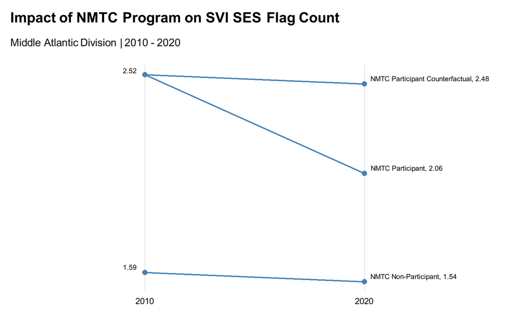

```r
slopegraph_plot(svidiv_viz_ses_nmtc, "NMTC Participant", "NMTC Non-Participant","Impact of NMTC Program on SVI SES Flag Count", paste0(census_division, " | 2010 - 2020"))
```

The slopegraph for SES SVI flags for the NMTC program indicates that in the Middle Atlantic Division our NMTC Participant Tracts had a notable decrease in socioeconomic social vulnerability flags in 2020 from the expected count of 2.48 for the counterfactual to 2.06 for the actual outcome.

## Visualize Median Home Value

```r
status <- c("NMTC Non-Participant",
             "NMTC Participant Counterfactual",
             "NMTC Participant",
             "NMTC Non-Participant",
             "NMTC Participant Counterfactual",
             "NMTC Participant")
year <- c(2010,
          2010,
          2010,
          2020,
          2020,
          2020)
outcome <- c(exp(m7_nmtc_div$coefficients[1]),
           exp(m7_nmtc_div$coefficients[1])*exp(m7_nmtc_div$coefficients[2]),
           exp(m7_nmtc_div$coefficients[1])*exp(m7_nmtc_div$coefficients[2]),
           exp(m7_nmtc_div$coefficients[1])*exp(m7_nmtc_div$coefficients[3]),
           exp(m7_nmtc_div$coefficients[1])*exp(m7_nmtc_div$coefficients[2])*exp(m7_nmtc_div$coefficients[3]),
           exp(m7_nmtc_div$coefficients[1])*exp(m7_nmtc_div$coefficients[2])*exp(m7_nmtc_div$coefficients[3])*exp(m7_nmtc_div$coefficients[length(m7_nmtc_div$coefficients)])
)

svidiv_viz_medhmv_nmtc <- data.frame(status, year, outcome)

### Note that instead of rounding like we did for SVI variables, we will be formatting our outcome as US dollars
svidiv_viz_medhmv_nmtc$outcome_label <- scales::dollar_format()(svidiv_viz_medhmv_nmtc$outcome)

svidiv_viz_medhmv_nmtc
```

```
##                            status year  outcome outcome_label
## 1            NMTC Non-Participant 2010 131767.2      $131,767
## 2 NMTC Participant Counterfactual 2010 114941.7      $114,942
## 3                NMTC Participant 2010 114941.7      $114,942
## 4            NMTC Non-Participant 2020 123150.8      $123,151
## 5 NMTC Participant Counterfactual 2020 107425.6      $107,426
## 6                NMTC Participant 2020 120052.5      $120,053
```

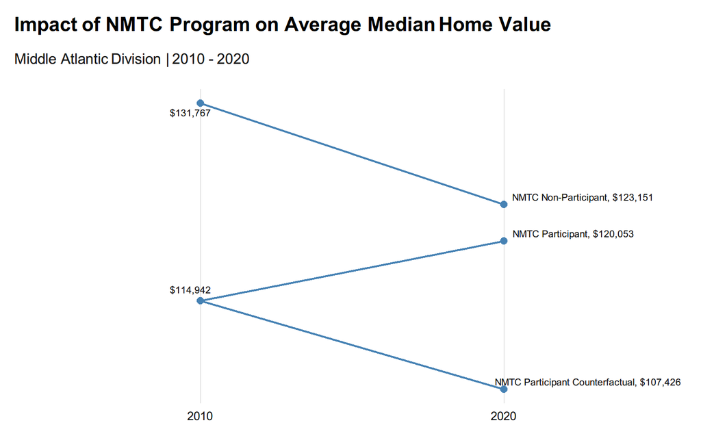

```r
slopegraph_plot(svidiv_viz_medhmv_nmtc, "NMTC Participant", "NMTC Non-Participant", "Impact of NMTC Program on Average Median Home Value", paste0(census_division, " | 2010 - 2020"))
```

When we control for metro-level effects, our average Median Home Value for tracts that did not receive NMTC dollars was ＄131,767.20 in 2010 when adjusted for inflation. This decreased to ＄123,150.8 in 2020, a -6.54% decrease in home values according to US Census data.

As a counterfactual, we can see that we would have expected the average Median Home Value of ＄107,425.60 in 2020 if it had decreased by -6.5%.

The slopegraph for Average Home Value for the NMTC program indicates that in the Middle Atlantic Division our NMTC Participant Tracts had a notable increase in 2020 from the expected home value of ＄107,426 for the counterfactual to ＄120,053 for the actual outcome. This increase is also in contrast to the general trend of decreasing average median home values within NMTC-eligible tracts in the division from 2010 to 2020.